# R. Class Assignment

Ezinga Richard_2023/HD07/3240U

2023-11-11

## Section A: Data Exploration 1

```r
library(dplyr)
meta_data <- read.csv("metaFile.csv")
# i
dim(meta_data)
```

```
## [1] 50  3
```

```r
# ii
meta_data %>% count(Treatment)
```

```
##   Treatment  n
## 1         0  9
## 2         1 10
## 3         2 10
## 4         3 11
## 5         4 10
```

```r
# iii
meta_data %>% count(Participant)
```

```
##   Participant  n
## 1           A 15
## 2           B 17
## 3           C 18
```

```r
# iv
treatment024 <- subset(meta_data, Treatment!=1 & Treatment!=3)
treatment024
```

```
##    sample_id Participant Treatment
## 1   sample_1           C         4
## 3   sample_3           B         2
## 6   sample_6           A         4
## 7   sample_7           B         0
## 9   sample_9           B         4
## 10 sample_10           C         0
## 11 sample_11           A         2
## 14 sample_14           C         2
## 15 sample_15           A         0
## 16 sample_16           C         4
## 18 sample_18           B         2
## 21 sample_21           A         4
## 22 sample_22           B         0
## 24 sample_24           B         4
## 25 sample_25           C         0
## 26 sample_26           A         2
## 29 sample_29           C         2
## 30 sample_30           A         0
## 31 sample_31           C         4
## 33 sample_33           B         2
## 36 sample_36           A         4
## 37 sample_37           B         0
## 39 sample_39           B         4
## 40 sample_40           C         0
## 41 sample_41           A         2
## 44 sample_44           C         2
## 45 sample_45           A         0
## 46 sample_46           C         4
## 48 sample_48           B         2
```

```r
# v

participantsAC <- subset(meta_data, Participant!= "B")
participantsAC
```

```
##    sample_id Participant Treatment
## 1   sample_1           C         4
## 4   sample_4           C         1
## 5   sample_5           C         3
## 6   sample_6           A         4
## 8   sample_8           A         1
## 10 sample_10           C         0
## 11 sample_11           A         2
## 12 sample_12           A         3
## 14 sample_14           C         2
## 15 sample_15           A         0
## 16 sample_16           C         4
## 19 sample_19           C         1
## 20 sample_20           C         3
## 21 sample_21           A         4
```

[output cut: 19 more lines]

```r
# vi
table(meta_data$Participant, meta_data$Treatment)
```

```
##
##     0 1 2 3 4
##   A 3 3 3 3 3
##   B 3 3 4 4 3
##   C 3 4 3 4 4
```

## Section B: Data Exploration 2

```r
conc_data <- read.csv("AssignmentFile.csv")
# i
dim(conc_data)
```

```
## [1] 50  4
```

```r
# ii
conc_average_per_column <- apply(conc_data[, 2:4], 2, mean)
conc_average_per_column
```

```
##    Conc1    Conc2    Conc3
## 2.235910 2.631801 2.579690
```

```r
# iii
Concmean <- apply(conc_data[, 2:4], 1, mean)
Concmean
```

```
##  [1] 3.824863 3.561779 1.499365 2.958203 2.390004 1.868026 2.409794 1.419867
##  [9] 3.306693 2.288922 2.056538 1.599757 2.451226 2.901506 3.258827 1.753767
## [17] 2.443834 2.657674 1.782624 2.034364 1.998999 2.163061 2.544692 2.452164
## [25] 2.092057 3.003388 3.313401 1.765348 1.624170 3.037058 2.448267 2.038269
## [33] 2.833067 1.957261 1.668823 2.192923 2.616311 3.646680 2.841996 2.949213
## [41] 3.229693 2.329251 3.211285 2.842079 2.998275 2.744949 1.683616 2.672564
## [49] 2.434259 2.322598
```

```r
# iv
conc_data <- data.frame(conc_data, Concmean)
conc_data
```

```
##      samples      Conc1     Conc2      Conc3 Concmean
## 1   sample_1 5.93804869 2.2877765  3.2487625 3.824863
## 2   sample_2 3.39846291 4.0508845  3.2359883 3.561779
## 3   sample_3 1.94647521 1.2918230  1.2597982 1.499365
## 4   sample_4 1.75043775 4.5088147  2.6153558 2.958203
## 5   sample_5 2.90319389 2.6006057  1.6662130 2.390004
## 6   sample_6 0.74662991 3.5212946  1.3361532 1.868026
## 7   sample_7 2.61412606 1.7075223  2.9077324 2.409794
## 8   sample_8 2.86823250 0.6855859  0.7057831 1.419867
## 9   sample_9 4.25332693 1.5380970  4.1286548 3.306693
## 10 sample_10 2.53152856 1.4914619  2.8437762 2.288922
## 11 sample_11 2.02469134 1.0988479  3.0460737 2.056538
## 12 sample_12 1.68888486 1.5382037  1.5721820 1.599757
## 13 sample_13 0.07948294 1.8417749  5.4324201 2.451226
## 14 sample_14 2.35002162 2.8437762  3.5107200 2.901506
```

[output cut: 36 more lines]

```r
# v
summary(conc_data[, 2:5])
```

```
##      Conc1             Conc2            Conc3            Concmean
##  Min.   :0.07948   Min.   :0.6856   Min.   :-0.2755   Min.   :1.420
##  1st Qu.:1.64835   1st Qu.:1.8380   1st Qu.: 1.8432   1st Qu.:2.035
##  Median :2.22227   Median :2.5963   Median : 2.6424   Median :2.446
##  Mean   :2.23591   Mean   :2.6318   Mean   : 2.5797   Mean   :2.482
##  3rd Qu.:2.72488   3rd Qu.:3.2873   3rd Qu.: 3.1898   3rd Qu.:2.937
##  Max.   :5.93805   Max.   :4.7706   Max.   : 5.4324   Max.   :3.825
```

```r
apply(conc_data[, 2:5], 2, sd)
```

```
##     Conc1     Conc2     Conc3  Concmean
## 1.0384617 0.9653108 1.1169179 0.6018165
```

```r
apply(conc_data[, 2:5], 2, var)
```

```
##     Conc1     Conc2     Conc3  Concmean
## 1.0784026 0.9318250 1.2475056 0.3621831
```

## Section C: Data Manipulation and Graphics

```r
# i
conc_data[,2:4]<-NULL
conc_data
```

```
##      samples Concmean
## 1   sample_1 3.824863
## 2   sample_2 3.561779
## 3   sample_3 1.499365
## 4   sample_4 2.958203
## 5   sample_5 2.390004
## 6   sample_6 1.868026
## 7   sample_7 2.409794
## 8   sample_8 1.419867
## 9   sample_9 3.306693
## 10 sample_10 2.288922
## 11 sample_11 2.056538
## 12 sample_12 1.599757
## 13 sample_13 2.451226
## 14 sample_14 2.901506
```

[output cut: 36 more lines]

```r
# ii
meta_data
```

```
##    sample_id Participant Treatment
## 1   sample_1           C         4
## 2   sample_2           B         3
## 3   sample_3           B         2
## 4   sample_4           C         1
## 5   sample_5           C         3
## 6   sample_6           A         4
## 7   sample_7           B         0
## 8   sample_8           A         1
## 9   sample_9           B         4
## 10 sample_10           C         0
## 11 sample_11           A         2
## 12 sample_12           A         3
## 13 sample_13           B         1
## 14 sample_14           C         2
```

[output cut: 36 more lines]

```r
colnames(conc_data)[1]<-"sample_id"
combined_data<-right_join(meta_data, conc_data,  by="sample_id")

# iii
head(combined_data)
```

```
##   sample_id Participant Treatment Concmean
## 1  sample_1           C         4 3.824863
## 2  sample_2           B         3 3.561779
## 3  sample_3           B         2 1.499365
## 4  sample_4           C         1 2.958203
## 5  sample_5           C         3 2.390004
## 6  sample_6           A         4 1.868026
```

```r
dim(combined_data)
```

```
## [1] 50  4
```

```r
colnames(combined_data)
```

```
## [1] "sample_id"   "Participant" "Treatment"   "Concmean"
```

```r
#iv
BC<-combined_data %>% filter(Participant != "A")
ParticipantsBC<-rbind(BC %>% filter(Treatment == 2), BC %>% filter(Treatment == 3), BC %>% filter(Treatment == 4))
ParticipantsBC
```

```
##    sample_id Participant Treatment Concmean
## 1   sample_3           B         2 1.499365
## 2  sample_14           C         2 2.901506
## 3  sample_18           B         2 2.657674
## 4  sample_29           C         2 1.624170
## 5  sample_33           B         2 2.833067
## 6  sample_44           C         2 2.842079
## 7  sample_48           B         2 2.672564
## 8   sample_2           B         3 3.561779
## 9   sample_5           C         3 2.390004
## 10 sample_17           B         3 2.443834
## 11 sample_20           C         3 2.034364
## 12 sample_32           B         3 2.038269
## 13 sample_35           C         3 1.668823
## 14 sample_47           B         3 1.683616
## 15 sample_50           C         3 2.322598
## 16  sample_1           C         4 3.824863
## 17  sample_9           B         4 3.306693
## 18 sample_16           C         4 1.753767
## 19 sample_24           B         4 2.452164
## 20 sample_31           C         4 2.448267
## 21 sample_39           B         4 2.841996
## 22 sample_46           C         4 2.744949
```

```r
# v
aggregate(ParticipantsBC["Concmean"], by=ParticipantsBC[c("Treatment","Participant")],mean)
```

```
##   Treatment Participant Concmean
## 1         2           B 2.415668
## 2         3           B 2.431874
## 3         4           B 2.866951
## 4         2           C 2.455918
## 5         3           C 2.103947
## 6         4           C 2.692961
```

```r
# vi
for (r in 1:nrow(combined_data)){
    if (combined_data[r,3]==0){
      combined_data[r,3] <- "very-low"
    } else if (combined_data[r,3]==1) {
      combined_data[r,3] <-"low"
    } else if (combined_data[r,3]==2) {
      combined_data[r,3] <- "moderate"
    } else if (combined_data[r,3]==3) {
      combined_data[r,3] <- "high"
    }else{
      combined_data[r,3] <- "very-high"
  }
}
combined_data
```

```
##    sample_id Participant Treatment Concmean
## 1   sample_1           C very-high 3.824863
## 2   sample_2           B      high 3.561779
## 3   sample_3           B  moderate 1.499365
## 4   sample_4           C       low 2.958203
## 5   sample_5           C      high 2.390004
## 6   sample_6           A very-high 1.868026
## 7   sample_7           B  very-low 2.409794
## 8   sample_8           A       low 1.419867
## 9   sample_9           B very-high 3.306693
## 10 sample_10           C  very-low 2.288922
## 11 sample_11           A  moderate 2.056538
## 12 sample_12           A      high 1.599757
## 13 sample_13           B       low 2.451226
## 14 sample_14           C  moderate 2.901506
```

[output cut: 36 more lines]

```r
#vii

f <-function(t){
  if (t==0){
    return ("very-low")
  } else if (t==1) {
    return ("low")
  } else if (t==2) {
    return ("moderate")
  } else if (t==3) {
    return ("high")
  } else {
    return ("very-high")
  }
}
#f(0)

combined_data<-right_join(meta_data, conc_data,  by="sample_id")
combined_data$Treatment <- sapply(combined_data$Treatment, f)
combined_data
```

```
##    sample_id Participant Treatment Concmean
## 1   sample_1           C very-high 3.824863
## 2   sample_2           B      high 3.561779
## 3   sample_3           B  moderate 1.499365
## 4   sample_4           C       low 2.958203
## 5   sample_5           C      high 2.390004
## 6   sample_6           A very-high 1.868026
## 7   sample_7           B  very-low 2.409794
## 8   sample_8           A       low 1.419867
## 9   sample_9           B very-high 3.306693
## 10 sample_10           C  very-low 2.288922
## 11 sample_11           A  moderate 2.056538
## 12 sample_12           A      high 1.599757
## 13 sample_13           B       low 2.451226
## 14 sample_14           C  moderate 2.901506
```

[output cut: 36 more lines]

```r
# viii
combined_data<-right_join(meta_data, conc_data,  by="sample_id")
system.time(for (r in 1:nrow(combined_data)){
    if (combined_data[r,3]==0){
      combined_data[r,3] <- "very-low"
    } else if (combined_data[r,3]==1) {
      combined_data[r,3] <-"low"
    } else if (combined_data[r,3]==2) {
      combined_data[r,3] <- "moderate"
    } else if (combined_data[r,3]==3) {
      combined_data[r,3] <- "high"
    }else{
      combined_data[r,3] <- "very-high"
  }
})
```

```
##    user  system elapsed
##   0.021   0.001   0.023
```

```r
combined_data<-right_join(meta_data, conc_data,  by="sample_id")
system.time(combined_data$Treatment <- sapply(combined_data$Treatment, f))
```

```
##    user  system elapsed
##   0.001   0.000   0.000
```

```r
combined_data
```

```
##    sample_id Participant Treatment Concmean
## 1   sample_1           C very-high 3.824863
## 2   sample_2           B      high 3.561779
## 3   sample_3           B  moderate 1.499365
## 4   sample_4           C       low 2.958203
## 5   sample_5           C      high 2.390004
## 6   sample_6           A very-high 1.868026
## 7   sample_7           B  very-low 2.409794
## 8   sample_8           A       low 1.419867
## 9   sample_9           B very-high 3.306693
## 10 sample_10           C  very-low 2.288922
## 11 sample_11           A  moderate 2.056538
## 12 sample_12           A      high 1.599757
## 13 sample_13           B       low 2.451226
## 14 sample_14           C  moderate 2.901506
```

[output cut: 36 more lines]

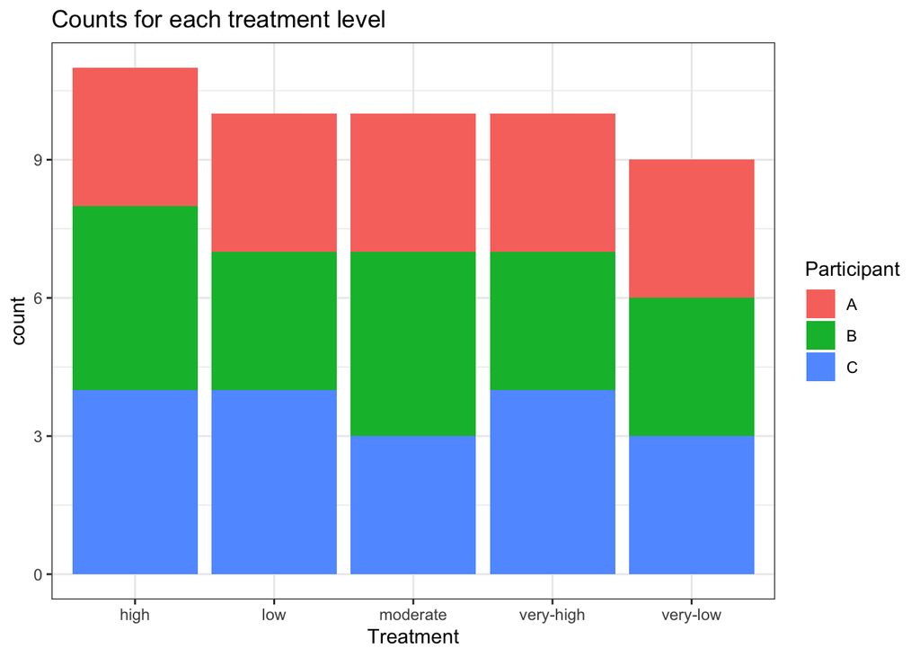

```r
#ix
library(ggplot2)
ggplot(combined_data, mapping = aes(x=Treatment, fill=Participant)) + geom_bar()+ theme_bw() +
  labs(title = "Counts for each treatment level")
```

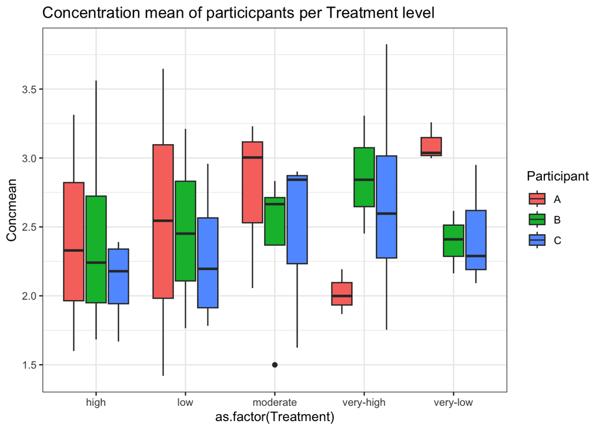

```r
ggplot(combined_data, mapping = aes( as.factor(Treatment),Concmean, fill = Participant)) + geom_boxplot() +
  labs(title = "Concentration mean of particicpants per Treatment level")+ theme_bw()
```

## Section D

```r
stats_file <- read.csv("statsFile.csv")

# 1
cor(stats_file$BMI,stats_file$BP)
```

```
## [1] 0.9997509
```

```r
cor.test(stats_file$BMI, stats_file$BP)
```

```
##
##  Pearson's product-moment correlation
##
## data:  stats_file$BMI and stats_file$BP
## t = 798.75, df = 318, p-value < 2.2e-16
## alternative hypothesis: true correlation is not equal to 0
## 95 percent confidence interval:
##  0.9996895 0.9998001
## sample estimates:
##       cor
## 0.9997509
```

```r
cor.test(stats_file$BMI, stats_file$BP, method = "pearson")
```

```
##
##  Pearson's product-moment correlation
##
## data:  stats_file$BMI and stats_file$BP
## t = 798.75, df = 318, p-value < 2.2e-16
## alternative hypothesis: true correlation is not equal to 0
## 95 percent confidence interval:
##  0.9996895 0.9998001
## sample estimates:
##       cor
## 0.9997509
```

```r
cov(stats_file$BMI, stats_file$BP)
```

```
## [1] 0.01065146
```

```r
## Comparison of means
mean(stats_file$BMI)
```

```
## [1] 3.185907
```

```r
mean(stats_file$BP)
```

```
## [1] 1.814074
```

```r
t.test(stats_file$BMI, stats_file$BP)
```

```
##
##  Welch Two Sample t-test
##
## data:  stats_file$BMI and stats_file$BP
## t = 121.36, df = 369.13, p-value < 2.2e-16
## alternative hypothesis: true difference in means is not equal to 0
## 95 percent confidence interval:
##  1.349605 1.394060
## sample estimates:
## mean of x mean of y
##  3.185907  1.814074
```

```r
## Comparison of variances
var(stats_file$BMI)
```

```
## [1] 0.03789084
```

```r
var(stats_file$BP)
```

```
## [1] 0.002995712
```

```r
var.test(stats_file$BMI, stats_file$BP)
```

```
##
##  F test to compare two variances
##
## data:  stats_file$BMI and stats_file$BP
## F = 12.648, num df = 319, denom df = 319, p-value < 2.2e-16
## alternative hypothesis: true ratio of variances is not equal to 1
## 95 percent confidence interval:
##  10.15190 15.75872
## sample estimates:
## ratio of variances
##           12.64836
```

```r
# 2
chisq.test(stats_file$Status, stats_file$Gender)
```

```
##
##  Pearson's Chi-squared test with Yates' continuity correction
##
## data:  stats_file$Status and stats_file$Gender
## X-squared = 0.86632, df = 1, p-value = 0.352
```

```r
chisq.test(table(stats_file$Status, stats_file$Gender))
```

```
##
##  Pearson's Chi-squared test with Yates' continuity correction
##
## data:  table(stats_file$Status, stats_file$Gender)
## X-squared = 0.86632, df = 1, p-value = 0.352
```

```r
# 3
model1 <- lm(BP ~ BMI, data = stats_file)
summary(model1)
```

```
##
## Call:
## lm(formula = BP ~ BMI, data = stats_file)
##
## Residuals:
##        Min         1Q     Median         3Q        Max
## -0.0080845 -0.0001705  0.0004430  0.0007507  0.0008477
##
## Coefficients:
##              Estimate Std. Error t value Pr(>|t|)
## (Intercept) 0.9184871  0.0011233   817.6   <2e-16 ***
## BMI         0.2811090  0.0003519   798.7   <2e-16 ***
## ---
## Signif. codes:  0 '***' 0.001 '**' 0.01 '*' 0.05 '.' 0.1 ' ' 1
##
## Residual standard error: 0.001224 on 318 degrees of freedom
## Multiple R-squared:  0.9995, Adjusted R-squared:  0.9995
## F-statistic: 6.38e+05 on 1 and 318 DF,  p-value: < 2.2e-16
```

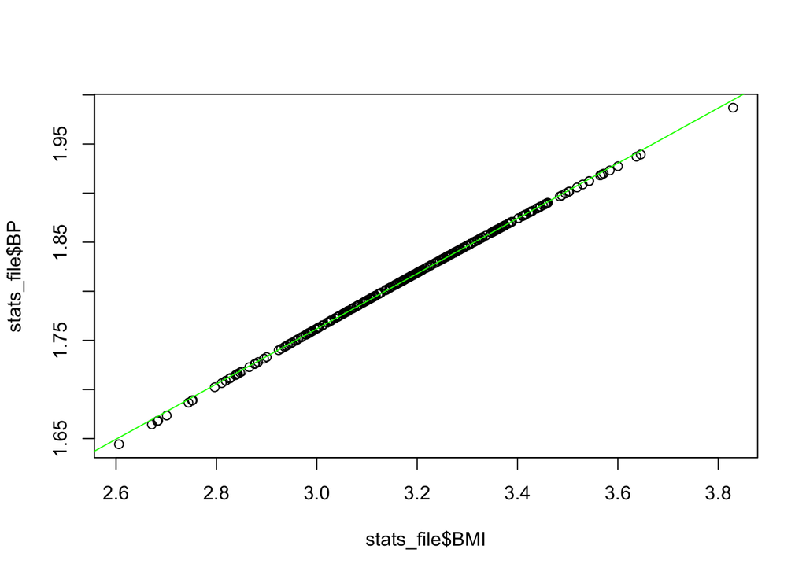

```r
plot(stats_file$BMI, stats_file$BP)
abline(model1, col = "Green")
```

```r
# 4
# Mean, Median
stats_file %>% group_by(Location) %>% summarise(mean = mean(BMI), median = median(BMI), variance = var(BMI))
```

```
## # A tibble: 3 × 4
##   Location  mean median variance
##   <chr>    <dbl>  <dbl>    <dbl>
## 1 A         3.18   3.21   0.0369
## 2 B         3.21   3.19   0.0395
## 3 C         3.17   3.17   0.0367
```

```r
anov_result <- aov(BMI~Location, stats_file)
summary(anov_result)
```

```
##              Df Sum Sq Mean Sq F value Pr(>F)
## Location      2  0.097 0.04834   1.278   0.28
## Residuals   317 11.991 0.03782
```

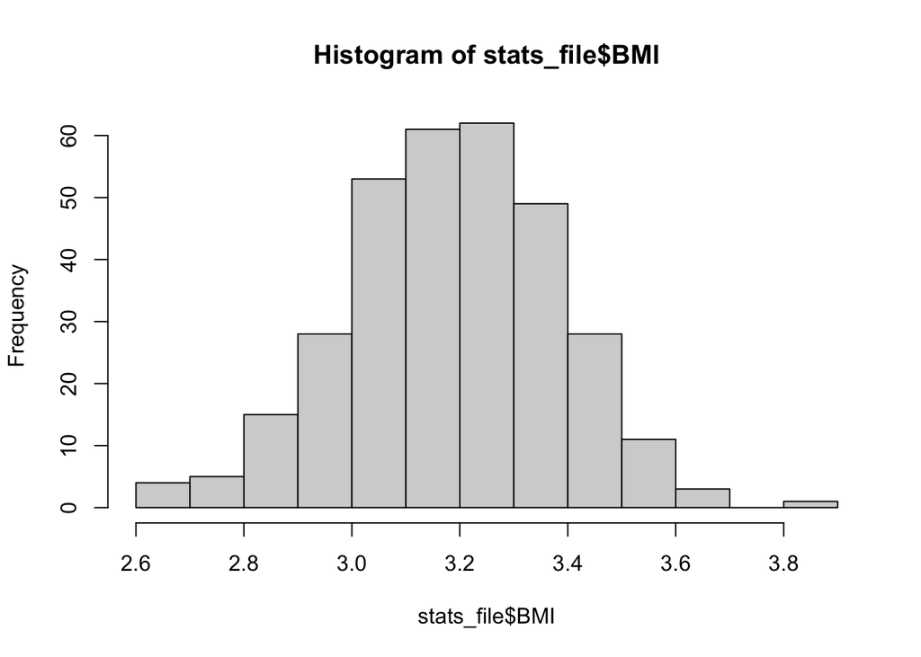

```r
hist(stats_file$BMI)
```

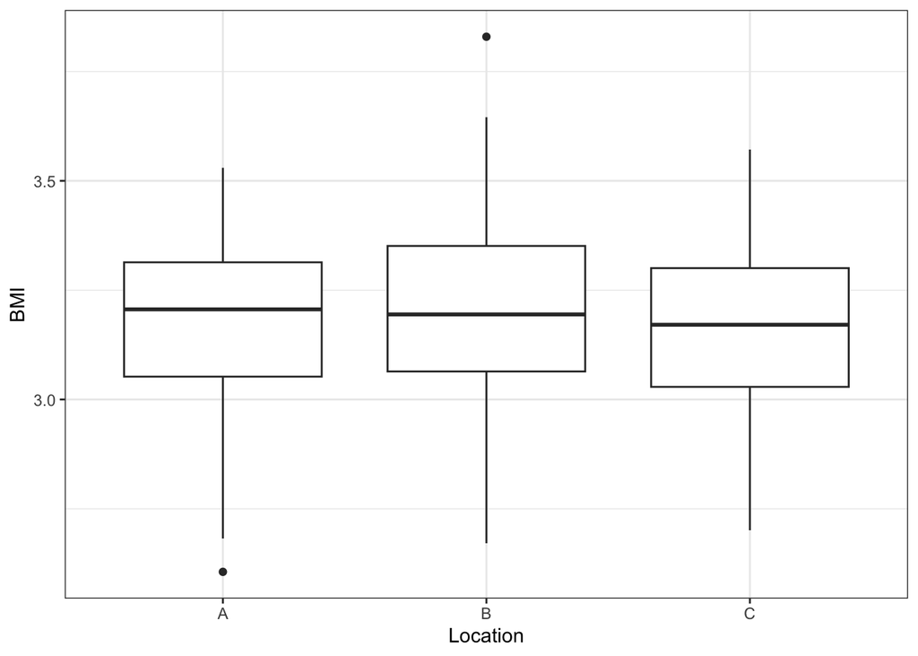

```r
ggplot(data = stats_file, mapping = aes(x = Location, y = BMI)) + geom_boxplot() + theme_bw()
```

```r
#5
dependancy <- glm(Status ~ BMI + BP, data = stats_file, family = "binomial")
summary(dependancy)
```

```
##
## Call:
## glm(formula = Status ~ BMI + BP, family = "binomial", data = stats_file)
##
## Coefficients:
##             Estimate Std. Error z value Pr(>|z|)
## (Intercept)   -11.64      84.53  -0.138    0.890
## BMI            -4.15      25.88  -0.160    0.873
## BP             13.67      92.02   0.149    0.882
##
## (Dispersion parameter for binomial family taken to be 1)
##
##     Null deviance: 443.30  on 319  degrees of freedom
## Residual deviance: 442.99  on 317  degrees of freedom
## AIC: 448.99
##
## Number of Fisher Scoring iterations: 3
```

Ratio of variances F-Test was used to compare variances Ho is True ratio of the variance = one p-value = < 0.005 Reject the null since the ratio of variance was > one Also, the Ho value (one) is not in the CI for all.

2). Used the Chiq-test of two independent variables (Status and Gender) The expected frequencies > 5 Ho is there is No significant association between the two variables (disease status and gender) p-value > 0.005 We fail to reject the null Therefore, No statistically significant association between disease status and gender

3). Simple linear regression model was used (Assess effect of BMI on BP) BP - Dependent BMI - Independent p-value < 0.05 Thus, the entire model is statistically significant Also, the high R squired values imply a better fit (thus positive relation)

4). Two different variables: BMI is quantitative and Sampling locations being qualitative Used Oneway anova test Assumptions: Independent variables Parametric Equal population variances Ho: There is no significant difference in the mean BMI values in the 3 sampling locations p-value > 0.005 We fail to reject the null

5). Since we are dealing with Binary outcomes, we used the Binary Logistic regression model. p-value > 0.005 BMI and BP are not predictors of disease status.